# Biostat 203B Homework 3

Due Feb 23 @ 11:59PM

Author

Jiaye Tian and UID: 306541095

#clear workspace, only keep ‘icu_cohort’ tibble: rm(list = setdiff(ls(), “icu_cohort”))

#if you want to interactive plot: library(plotly) p <- icu |> … ggplotly(p)

Load necessary libraries (you can add more as needed).

```r
library(arrow)
library(gtsummary)
library(memuse)
library(pryr)
library(R.utils)
library(tidyverse)
library(ggplot2)
library(lubridate)
```

Display your machine memory.

```r
memuse::Sys.meminfo()
```

```
Totalram:  16.000 GiB
Freeram:    5.816 GiB
```

In this exercise, we use tidyverse (ggplot2, dplyr, etc) to explore the [MIMIC-IV](https://physionet.org/content/mimiciv/3.1/) data introduced in [homework 1](https://ucla-biostat-203b.github.io/2025winter/hw/hw1/hw1.html) and to build a cohort of ICU stays.

## Q1. Visualizing patient trajectory

Visualizing a patient’s encounters in a health care system is a common task in clinical data analysis. In this question, we will visualize a patient’s ADT (admission-discharge-transfer) history and ICU vitals in the MIMIC-IV data.

### Q1.1 ADT history

Hint: We need to pull information from data files `patients.csv.gz`, `admissions.csv.gz`, `transfers.csv.gz`, `labevents.csv.gz`, `procedures_icd.csv.gz`, `diagnoses_icd.csv.gz`, `d_icd_procedures.csv.gz`, and `d_icd_diagnoses.csv.gz`. For the big file `labevents.csv.gz`, use the Parquet format you generated in Homework 2. For reproducibility, make the Parquet folder `labevents_pq` available at the current working directory `hw3`, for example, by a symbolic link. Make your code reproducible.

```r
patients_tble <- read_csv("~/mimic/hosp/patients.csv.gz") |>
  print(width = Inf)
```

```
# A tibble: 364,627 × 6
   subject_id gender anchor_age anchor_year anchor_year_group dod
        <dbl> <chr>       <dbl>       <dbl> <chr>             <date>
 1   10000032 F              52        2180 2014 - 2016       2180-09-09
 2   10000048 F              23        2126 2008 - 2010       NA
 3   10000058 F              33        2168 2020 - 2022       NA
 4   10000068 F              19        2160 2008 - 2010       NA
 5   10000084 M              72        2160 2017 - 2019       2161-02-13
 6   10000102 F              27        2136 2008 - 2010       NA
 7   10000108 M              25        2163 2014 - 2016       NA
 8   10000115 M              24        2154 2017 - 2019       NA
 9   10000117 F              48        2174 2008 - 2010       NA
10   10000161 M              60        2163 2020 - 2022       NA
# ℹ 364,617 more rows
```

```r
admissions_tble <- read_csv("~/mimic/hosp/admissions.csv.gz") |>
  print(width = Inf)
```

```
# A tibble: 546,028 × 16
   subject_id  hadm_id admittime           dischtime           deathtime
        <dbl>    <dbl> <dttm>              <dttm>              <dttm>
 1   10000032 22595853 2180-05-06 22:23:00 2180-05-07 17:15:00 NA
 2   10000032 22841357 2180-06-26 18:27:00 2180-06-27 18:49:00 NA
 3   10000032 25742920 2180-08-05 23:44:00 2180-08-07 17:50:00 NA
 4   10000032 29079034 2180-07-23 12:35:00 2180-07-25 17:55:00 NA
 5   10000068 25022803 2160-03-03 23:16:00 2160-03-04 06:26:00 NA
 6   10000084 23052089 2160-11-21 01:56:00 2160-11-25 14:52:00 NA
 7   10000084 29888819 2160-12-28 05:11:00 2160-12-28 16:07:00 NA
 8   10000108 27250926 2163-09-27 23:17:00 2163-09-28 09:04:00 NA
 9   10000117 22927623 2181-11-15 02:05:00 2181-11-15 14:52:00 NA
10   10000117 27988844 2183-09-18 18:10:00 2183-09-21 16:30:00 NA
   admission_type    admit_provider_id admission_location     discharge_location
   <chr>             <chr>             <chr>                  <chr>
```

[output cut: 35 more lines]

```r
transfers_tble <- read_csv("~/mimic/hosp/transfers.csv.gz") |>
  print(width = Inf)
```

```
# A tibble: 2,413,581 × 7
   subject_id  hadm_id transfer_id eventtype careunit
        <dbl>    <dbl>       <dbl> <chr>     <chr>
 1   10000032 22595853    33258284 ED        Emergency Department
 2   10000032 22595853    35223874 admit     Transplant
 3   10000032 22595853    36904543 discharge UNKNOWN
 4   10000032 22841357    34100253 discharge UNKNOWN
 5   10000032 22841357    34703856 admit     Transplant
 6   10000032 22841357    38112554 ED        Emergency Department
 7   10000032 25742920    35509340 admit     Transplant
 8   10000032 25742920    35968195 ED        Emergency Department
 9   10000032 25742920    38883756 discharge UNKNOWN
10   10000032 29079034    32952584 ED        Emergency Department
   intime              outtime
   <dttm>              <dttm>
 1 2180-05-06 19:17:00 2180-05-06 23:30:00
 2 2180-05-06 23:30:00 2180-05-07 17:21:27
 3 2180-05-07 17:21:27 NA
 4 2180-06-27 18:49:12 NA
 5 2180-06-26 21:31:00 2180-06-27 18:49:12
 6 2180-06-26 15:54:00 2180-06-26 21:31:00
 7 2180-08-06 01:44:00 2180-08-07 17:50:44
 8 2180-08-05 20:58:00 2180-08-06 01:44:00
 9 2180-08-07 17:50:44 NA
10 2180-07-22 16:24:00 2180-07-23 05:54:00
# ℹ 2,413,571 more rows
```

```r
procedures_icd_tble <- read_csv("~/mimic/hosp/procedures_icd.csv.gz") |>
  print(width = Inf)
```

```
# A tibble: 859,655 × 6
   subject_id  hadm_id seq_num chartdate  icd_code icd_version
        <dbl>    <dbl>   <dbl> <date>     <chr>          <dbl>
 1   10000032 22595853       1 2180-05-07 5491               9
 2   10000032 22841357       1 2180-06-27 5491               9
 3   10000032 25742920       1 2180-08-06 5491               9
 4   10000068 25022803       1 2160-03-03 8938               9
 5   10000117 27988844       1 2183-09-19 0QS734Z           10
 6   10000280 25852320       1 2151-03-18 8938               9
 7   10000560 28979390       1 2189-10-16 5551               9
 8   10000635 26134563       1 2136-06-19 3734               9
 9   10000635 26134563       2 2136-06-19 3728               9
10   10000635 26134563       3 2136-06-19 3727               9
# ℹ 859,645 more rows
```

```r
diagnoses_icd_tble <- read_csv("~/mimic/hosp/diagnoses_icd.csv.gz") |>
  print(width = Inf)
```

```
# A tibble: 6,364,488 × 5
   subject_id  hadm_id seq_num icd_code icd_version
        <dbl>    <dbl>   <dbl> <chr>          <dbl>
 1   10000032 22595853       1 5723               9
 2   10000032 22595853       2 78959              9
 3   10000032 22595853       3 5715               9
 4   10000032 22595853       4 07070              9
 5   10000032 22595853       5 496                9
 6   10000032 22595853       6 29680              9
 7   10000032 22595853       7 30981              9
 8   10000032 22595853       8 V1582              9
 9   10000032 22841357       1 07071              9
10   10000032 22841357       2 78959              9
# ℹ 6,364,478 more rows
```

```r
d_icd_procedures_tble <- read_csv("~/mimic/hosp/d_icd_procedures.csv.gz") |>
  print(width = Inf)
```

```
# A tibble: 86,423 × 3
   icd_code icd_version
   <chr>          <dbl>
 1 0001               9
 2 0002               9
 3 0003               9
 4 0009               9
 5 001               10
 6 0010               9
 7 0011               9
 8 0012               9
 9 0013               9
10 0014               9
   long_title
   <chr>
 1 Therapeutic ultrasound of vessels of head and neck
 2 Therapeutic ultrasound of heart
 3 Therapeutic ultrasound of peripheral vascular vessels
 4 Other therapeutic ultrasound
 5 Central Nervous System and Cranial Nerves, Bypass
 6 Implantation of chemotherapeutic agent
 7 Infusion of drotrecogin alfa (activated)
 8 Administration of inhaled nitric oxide
 9 Injection or infusion of nesiritide
10 Injection or infusion of oxazolidinone class of antibiotics
# ℹ 86,413 more rows
```

```r
d_icd_diagnoses_tble <- read_csv("~/mimic/hosp/d_icd_diagnoses.csv.gz") |>
  print(width = Inf)
```

```
# A tibble: 112,107 × 3
   icd_code icd_version long_title
   <chr>          <dbl> <chr>
 1 0010               9 Cholera due to vibrio cholerae
 2 0011               9 Cholera due to vibrio cholerae el tor
 3 0019               9 Cholera, unspecified
 4 0020               9 Typhoid fever
 5 0021               9 Paratyphoid fever A
 6 0022               9 Paratyphoid fever B
 7 0023               9 Paratyphoid fever C
 8 0029               9 Paratyphoid fever, unspecified
 9 0030               9 Salmonella gastroenteritis
10 0031               9 Salmonella septicemia
# ℹ 112,097 more rows
```

```r
lab_events <- open_dataset("~/203b/hw/hw3/labevents_pq",
                           format = "parquet") %>%
  select(subject_id, charttime, itemid, storetime, valuenum) %>%
  collect()
print(lab_events, width = Inf)
```

```
# A tibble: 158,374,764 × 5
   subject_id charttime           itemid storetime           valuenum
        <int> <dttm>               <int> <dttm>                 <dbl>
 1   10000032 2180-03-23 04:51:00  50931 2180-03-23 08:56:00       95
 2   10000032 2180-03-23 04:51:00  51071 2180-03-23 09:00:00       NA
 3   10000032 2180-03-23 04:51:00  51074 2180-03-23 09:00:00       NA
 4   10000032 2180-03-23 04:51:00  51075 2180-03-23 09:00:00       NA
 5   10000032 2180-03-23 04:51:00  51079 2180-03-23 09:00:00       NA
 6   10000032 2180-03-23 04:51:00  51087 NA                        NA
 7   10000032 2180-03-23 04:51:00  51089 2180-03-23 09:15:00       NA
 8   10000032 2180-03-23 04:51:00  51090 2180-03-23 09:00:00       NA
 9   10000032 2180-03-23 04:51:00  51092 2180-03-23 09:00:00       NA
10   10000032 2180-03-23 04:51:00  50853 2180-03-25 04:06:00       15
# ℹ 158,374,754 more rows
```

```r
subject_id <- 10063848

adt_data <- transfers_tble %>%
  filter(subject_id == !!subject_id & !is.na(intime) & !is.na(outtime)) %>%
  mutate(intime = as.POSIXct(intime,
                             format="%Y-%m-%d %H:%M:%S",
                             tz="UTC"),
         outtime = as.POSIXct(outtime,
                              format="%Y-%m-%d %H:%M:%S",
                              tz="UTC"))

lab_data <- lab_events %>%
  filter(subject_id == !!subject_id) %>%
  distinct(subject_id, charttime, itemid, .keep_all = TRUE) %>%
  mutate(charttime = as.POSIXct(charttime, tz="UTC"))

patient_info <- admissions_tble %>%
  filter(subject_id == !!subject_id) %>%
  select(subject_id, race) %>%
  distinct() %>%
  left_join(patients_tble %>% select(subject_id, gender, anchor_age),
            by = "subject_id")

diagnoses_icd <- diagnoses_icd_tble %>%
  mutate(icd_code = str_remove(icd_code, "^0+"),
         icd_version = as.character(icd_version))

d_icd_diagnoses <- d_icd_diagnoses_tble %>%
  mutate(icd_code = str_remove(icd_code, "^0+"),
         icd_version = as.character(icd_version))

diagnosis_data <- diagnoses_icd_tble %>%
  filter(subject_id == !!subject_id) %>%
  left_join(d_icd_diagnoses_tble, by = c("icd_code", "icd_version")) %>%
  left_join(admissions_tble %>% select(subject_id, admittime),
            by = "subject_id") %>%
  arrange(admittime) %>%
  slice(1:3)
procedure_data <- procedures_icd_tble %>%
  filter(subject_id == !!subject_id & !is.na(chartdate)) %>%
  left_join(d_icd_procedures_tble, by = "icd_code") %>%
  mutate(chartdate = as.POSIXct(chartdate,
                                format="%Y-%m-%d",
                                tz="UTC"),
         procedure_label = ifelse(is.na(long_title),
                                  "Unknown Procedure",
                                  str_trunc(long_title, 30,
                                            side = "right")))
```

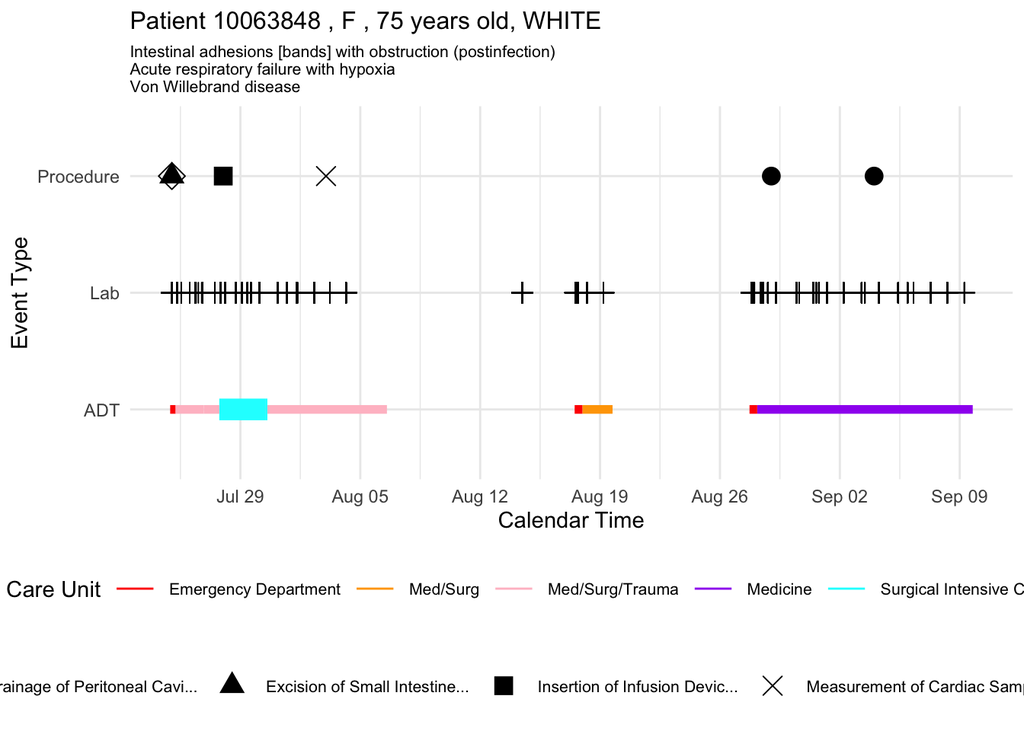

```r
title_text <- paste("Patient", subject_id, ",",
                    patient_info$gender, ",",
                    patient_info$anchor_age, "years old,",
                    patient_info$race)

subtitle_text <- diagnosis_data %>%
  filter(!is.na(long_title)) %>%
  pull(long_title) %>%
  paste(collapse = "\n")

procedure_data <- procedure_data %>%
  mutate(procedure_label = str_trunc(long_title, 30, side = "right"))

ggplot() +

  geom_point(data = procedure_data,
             aes(x = chartdate, y = "Procedure",
                 shape = factor(procedure_label)),
             size = 4) +

  # ADT
  geom_segment(data = adt_data,
               aes(x = intime, xend = outtime, y = "ADT",
                   color = careunit,
                   linewidth = ifelse(str_detect(careunit,
                                                 "ICU|CCU|SICU"), 5, 2))
               ) +
  scale_linewidth_identity() +

  # Lab
  geom_point(data = lab_data,
             aes(x = charttime, y = "Lab"),
             shape = 3, size = 3, color = "black") +

  scale_x_datetime(date_labels = "%b %d", date_breaks = "7 days") +

  theme_minimal() +
  labs(title = title_text,
       subtitle = subtitle_text,
       x = "Calendar Time",
       y = "Event Type",
       color = "Care Unit",
       shape = "Procedure") +

  # Care Unit
  scale_color_manual(values = c("red",
                                "orange",
                                "pink",
                                "purple",
                                "cyan")) +

  # Procedure
  scale_shape_manual(values = c(16, 17, 15, 4, 5)) +

  guides(
    color = guide_legend(title = "Care Unit", nrow = 1),
    shape = guide_legend(title = "Procedure", nrow = 1)
  ) +

  theme(
    legend.position = "bottom",
    legend.box = "vertical",
    legend.spacing.y = unit(0.5, "cm"),
    legend.text = element_text(size = 8),
    plot.title = element_text(size = 12, hjust = 0),
    plot.subtitle = element_text(size = 8, hjust = 0),
    legend.key.size = unit(0.8, "cm")
  )
```

Do a similar visualization for the patient with `subject_id` 10063848 using ggplot.

### Q1.2 ICU stays

ICU stays are a subset of ADT history. This figure shows the vitals of the patient `10001217` during ICU stays. The x-axis is the calendar time, and the y-axis is the value of the vital. The color of the line represents the type of vital. The facet grid shows the abbreviation of the vital and the stay ID.

```r
icu_stays_tble <- read_csv("~/mimic/icu/icustays.csv.gz") |>
  print(width = Inf)
```

```
# A tibble: 94,458 × 8
   subject_id  hadm_id  stay_id first_careunit
        <dbl>    <dbl>    <dbl> <chr>
 1   10000032 29079034 39553978 Medical Intensive Care Unit (MICU)
 2   10000690 25860671 37081114 Medical Intensive Care Unit (MICU)
 3   10000980 26913865 39765666 Medical Intensive Care Unit (MICU)
 4   10001217 24597018 37067082 Surgical Intensive Care Unit (SICU)
 5   10001217 27703517 34592300 Surgical Intensive Care Unit (SICU)
 6   10001725 25563031 31205490 Medical/Surgical Intensive Care Unit (MICU/SICU)
 7   10001843 26133978 39698942 Medical/Surgical Intensive Care Unit (MICU/SICU)
 8   10001884 26184834 37510196 Medical Intensive Care Unit (MICU)
 9   10002013 23581541 39060235 Cardiac Vascular Intensive Care Unit (CVICU)
10   10002114 27793700 34672098 Coronary Care Unit (CCU)
   last_careunit                                    intime
   <chr>                                            <dttm>
```

[output cut: 23 more lines]

```r
chartevents <- read_csv("~/203b/hw/hw3/chartevents_filtered.csv") |>
  print(width = Inf)
```

```
# A tibble: 5,069,858 × 11
   subject_id  hadm_id  stay_id caregiver_id charttime
        <dbl>    <dbl>    <dbl>        <dbl> <dttm>
 1   10000032 29079034 39553978        18704 2180-07-23 14:00:00
 2   10000032 29079034 39553978        18704 2180-07-23 14:11:00
 3   10000032 29079034 39553978        18704 2180-07-23 14:11:00
 4   10000032 29079034 39553978        18704 2180-07-23 14:12:00
 5   10000032 29079034 39553978        18704 2180-07-23 14:12:00
 6   10000032 29079034 39553978        18704 2180-07-23 14:30:00
 7   10000032 29079034 39553978        18704 2180-07-23 14:30:00
 8   10000032 29079034 39553978        18704 2180-07-23 14:30:00
 9   10000032 29079034 39553978        18704 2180-07-23 14:30:00
10   10000032 29079034 39553978        18704 2180-07-23 15:00:00
   storetime           itemid value valuenum valueuom warning
   <dttm>               <dbl> <dbl>    <dbl> <chr>      <dbl>
 1 2180-07-23 14:20:00 223761  98.7     98.7 °F             0
 2 2180-07-23 14:17:00 220179  84       84   mmHg           0
 3 2180-07-23 14:17:00 220181  56       56   mmHg           0
 4 2180-07-23 14:17:00 220045  91       91   bpm            0
 5 2180-07-23 14:17:00 220210  24       24   insp/min       0
 6 2180-07-23 14:43:00 220045  93       93   bpm            0
 7 2180-07-23 14:43:00 220179  95       95   mmHg           0
 8 2180-07-23 14:43:00 220181  67       67   mmHg           0
 9 2180-07-23 14:43:00 220210  21       21   insp/min       0
10 2180-07-23 15:34:00 220045  94       94   bpm            0
# ℹ 5,069,848 more rows
```

```r
icu_stays <- icu_stays_tble %>%
  filter(subject_id == 10001217) %>%
  mutate(intime = as.POSIXct(intime, tz = "UTC"),
         outtime = as.POSIXct(outtime, tz = "UTC")) %>%
  select(subject_id, stay_id, intime, outtime)

vitals_data <- chartevents %>%
  filter(subject_id == 10001217, !is.na(valuenum)) %>%
  select(subject_id, stay_id, charttime, itemid, valuenum) %>%
  mutate(
    stay_id = as.double(stay_id),
    charttime = as.POSIXct(charttime, tz = "UTC")
  ) %>%
  inner_join(icu_stays, by = "stay_id") %>%
  filter(charttime >= intime & charttime <= outtime)

print(vitals_data)
```

```
# A tibble: 218 × 8
   subject_id.x  stay_id charttime           itemid valuenum subject_id.y
          <dbl>    <dbl> <dttm>               <dbl>    <dbl>        <dbl>
 1     10001217 37067082 2157-11-20 19:19:00 220045     86       10001217
 2     10001217 37067082 2157-11-20 19:19:00 220179    151       10001217
 3     10001217 37067082 2157-11-20 19:19:00 220181    104       10001217
 4     10001217 37067082 2157-11-20 19:19:00 220210     18       10001217
 5     10001217 37067082 2157-11-20 19:31:00 223761     98.5     10001217
 6     10001217 37067082 2157-11-20 20:00:00 220045     91       10001217
 7     10001217 37067082 2157-11-20 20:00:00 220179    143       10001217
 8     10001217 37067082 2157-11-20 20:00:00 220181     95       10001217
 9     10001217 37067082 2157-11-20 20:00:00 220210     24       10001217
10     10001217 37067082 2157-11-20 21:00:00 220045     95       10001217
# ℹ 208 more rows
# ℹ 2 more variables: intime <dttm>, outtime <dttm>
```

```r
vitals_data <- vitals_data %>%
  mutate(vital_label = case_when(
    itemid %in% c(220045) ~ "HR",
    itemid %in% c(220179) ~ "NBPd",
    itemid %in% c(220181) ~ "NBPs",
    itemid %in% c(220210) ~ "RR",
    itemid %in% c(223761) ~ "Temperature",
    TRUE ~ NA_character_
  )) %>%
  filter(!is.na(vital_label)) %>%
  group_by(stay_id) %>%
  mutate(relative_charttime = as.numeric(difftime(charttime,
                                                  min(charttime),
                                                  units = "hours"))
         ) %>%
  ungroup()
```

[figure not shown]

```r
ggplot(vitals_data, aes(x = relative_charttime,
                        y = valuenum,
                        color = vital_label)) +
  geom_line() +
  geom_point(size = 2) +
  facet_grid(vital_label ~ stay_id, scales = "free_y", switch = "y") +
  theme_minimal() +
  labs(
    title = paste("Patient", unique(vitals_data$subject_id), "ICU stays - Vitals"),
    x = "Time",
    y = "Vital Value"
  ) +
  theme(
    axis.text.x = element_text(angle = 45, hjust = 1),
    strip.text.y = element_text(angle = 0, hjust = 1),
    legend.position = "none",
    panel.grid.major = element_line(color = "grey90")
  )
```

Do a similar visualization for the patient `10063848`.

## Q2. ICU stays

`icustays.csv.gz` (https://mimic.mit.edu/docs/iv/modules/icu/icustays/) contains data about Intensive Care Units (ICU) stays. The first 10 lines are

```bash
zcat < ~/mimic/icu/icustays.csv.gz | head
```

```
subject_id,hadm_id,stay_id,first_careunit,last_careunit,intime,outtime,los
10000032,29079034,39553978,Medical Intensive Care Unit (MICU),Medical Intensive Care Unit (MICU),2180-07-23 14:00:00,2180-07-23 23:50:47,0.4102662037037037
10000690,25860671,37081114,Medical Intensive Care Unit (MICU),Medical Intensive Care Unit (MICU),2150-11-02 19:37:00,2150-11-06 17:03:17,3.8932523148148146
10000980,26913865,39765666,Medical Intensive Care Unit (MICU),Medical Intensive Care Unit (MICU),2189-06-27 08:42:00,2189-06-27 20:38:27,0.4975347222222222
10001217,24597018,37067082,Surgical Intensive Care Unit (SICU),Surgical Intensive Care Unit (SICU),2157-11-20 19:18:02,2157-11-21 22:08:00,1.1180324074074075
10001217,27703517,34592300,Surgical Intensive Care Unit (SICU),Surgical Intensive Care Unit (SICU),2157-12-19 15:42:24,2157-12-20 14:27:41,0.948113425925926
10001725,25563031,31205490,Medical/Surgical Intensive Care Unit (MICU/SICU),Medical/Surgical Intensive Care Unit (MICU/SICU),2110-04-11 15:52:22,2110-04-12 23:59:56,1.338587962962963
10001843,26133978,39698942,Medical/Surgical Intensive Care Unit (MICU/SICU),Medical/Surgical Intensive Care Unit (MICU/SICU),2134-12-05 18:50:03,2134-12-06 14:38:26,0.8252662037037037
10001884,26184834,37510196,Medical Intensive Care Unit (MICU),Medical Intensive Care Unit (MICU),2131-01-11 04:20:05,2131-01-20 08:27:30,9.17181712962963
10002013,23581541,39060235,Cardiac Vascular Intensive Care Unit (CVICU),Cardiac Vascular Intensive Care Unit (CVICU),2160-05-18 10:00:53,2160-05-19 17:33:33,1.314351851851852
```

### Q2.1 Ingestion

Import `icustays.csv.gz` as a tibble `icustays_tble`.

```r
icustays_tble <- read_csv("~/mimic/icu/icustays.csv.gz") |>
  print(width = Inf)
```

```
# A tibble: 94,458 × 8
   subject_id  hadm_id  stay_id first_careunit
        <dbl>    <dbl>    <dbl> <chr>
 1   10000032 29079034 39553978 Medical Intensive Care Unit (MICU)
 2   10000690 25860671 37081114 Medical Intensive Care Unit (MICU)
 3   10000980 26913865 39765666 Medical Intensive Care Unit (MICU)
 4   10001217 24597018 37067082 Surgical Intensive Care Unit (SICU)
 5   10001217 27703517 34592300 Surgical Intensive Care Unit (SICU)
 6   10001725 25563031 31205490 Medical/Surgical Intensive Care Unit (MICU/SICU)
 7   10001843 26133978 39698942 Medical/Surgical Intensive Care Unit (MICU/SICU)
 8   10001884 26184834 37510196 Medical Intensive Care Unit (MICU)
 9   10002013 23581541 39060235 Cardiac Vascular Intensive Care Unit (CVICU)
10   10002114 27793700 34672098 Coronary Care Unit (CCU)
   last_careunit                                    intime
   <chr>                                            <dttm>
```

[output cut: 23 more lines]

### Q2.2 Summary and visualization

How many unique `subject_id`? Can a `subject_id` have multiple ICU stays? Summarize the number of ICU stays per `subject_id` by graphs.

```r
unique_subjects <- icustays_tble %>%
  distinct(subject_id) %>%
  nrow()
print(unique_subjects)
```

```
[1] 65366
```

```r
icu_stay_counts <- icustays_tble %>%
  count(subject_id) %>%
  arrange(desc(n))

print(icu_stay_counts)
```

```
# A tibble: 65,366 × 2
   subject_id     n
        <dbl> <int>
 1   12468016    41
 2   18358138    37
 3   17585185    34
 4   17295976    31
 5   13269859    30
 6   18676703    27
 7   12517625    26
 8   11281568    25
 9   15229355    25
10   15455517    25
# ℹ 65,356 more rows
```

```r
icu_summary <- icu_stay_counts %>%
  summarize(
    mean_stays = mean(n),
    median_stays = median(n),
    min_stays = min(n),
    max_stays = max(n)
  )
print(icu_summary)
```

```
# A tibble: 1 × 4
  mean_stays median_stays min_stays max_stays
       <dbl>        <dbl>     <int>     <int>
1       1.45            1         1        41
```

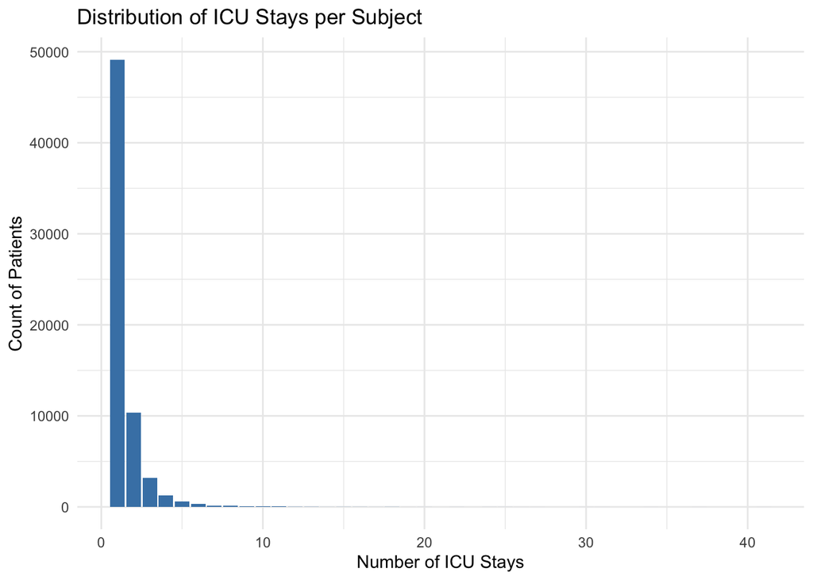

```r
ggplot(icu_stay_counts, aes(x = n)) +
  geom_bar(fill = "steelblue") +
  labs(title = "Distribution of ICU Stays per Subject",
       x = "Number of ICU Stays",
       y = "Count of Patients") +
  theme_minimal()
```

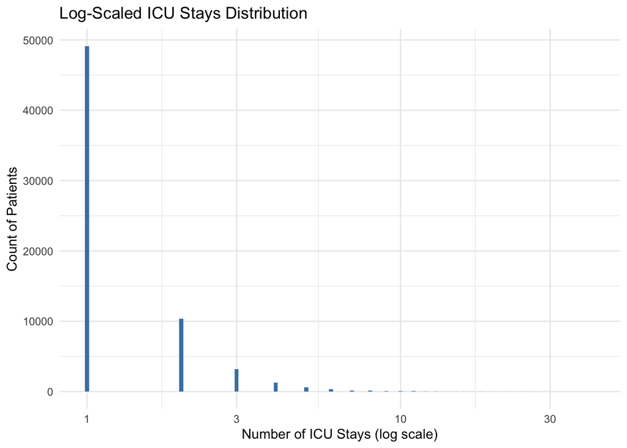

```r
ggplot(icu_stay_counts, aes(x = n)) +
  geom_bar(fill = "steelblue") +
  scale_x_log10() +
  labs(title = "Log-Scaled ICU Stays Distribution",
       x = "Number of ICU Stays (log scale)",
       y = "Count of Patients") +
  theme_minimal()
```

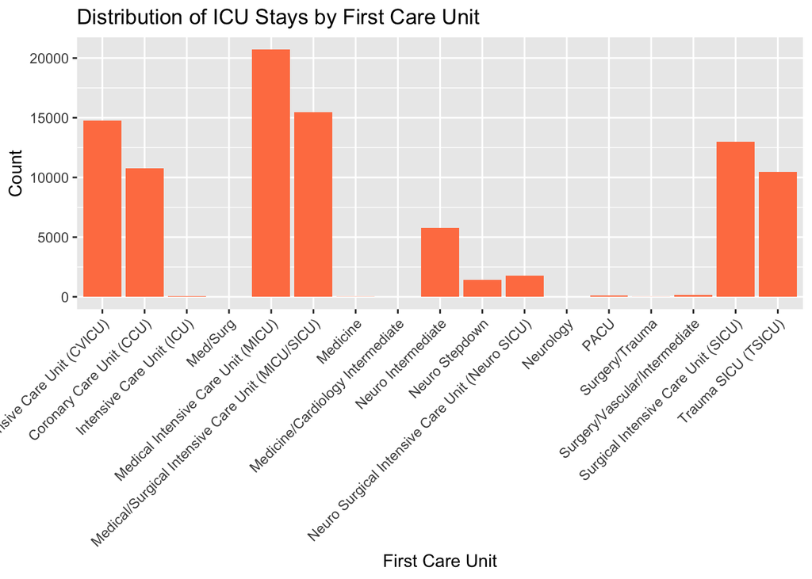

```r
ggplot(icustays_tble, aes(x = first_careunit)) +
  geom_bar(fill = "coral") +
  labs(title = "Distribution of ICU Stays by First Care Unit",
       x = "First Care Unit",
       y = "Count") +
  theme(axis.text.x = element_text(angle = 45, hjust = 1))
```

## Q3. `admissions` data

Information of the patients admitted into hospital is available in `admissions.csv.gz`. See https://mimic.mit.edu/docs/iv/modules/hosp/admissions/ for details of each field in this file. The first 10 lines are

```bash
zcat < ~/mimic/hosp/admissions.csv.gz | head
```

```
subject_id,hadm_id,admittime,dischtime,deathtime,admission_type,admit_provider_id,admission_location,discharge_location,insurance,language,marital_status,race,edregtime,edouttime,hospital_expire_flag
10000032,22595853,2180-05-06 22:23:00,2180-05-07 17:15:00,,URGENT,P49AFC,TRANSFER FROM HOSPITAL,HOME,Medicaid,English,WIDOWED,WHITE,2180-05-06 19:17:00,2180-05-06 23:30:00,0
10000032,22841357,2180-06-26 18:27:00,2180-06-27 18:49:00,,EW EMER.,P784FA,EMERGENCY ROOM,HOME,Medicaid,English,WIDOWED,WHITE,2180-06-26 15:54:00,2180-06-26 21:31:00,0
10000032,25742920,2180-08-05 23:44:00,2180-08-07 17:50:00,,EW EMER.,P19UTS,EMERGENCY ROOM,HOSPICE,Medicaid,English,WIDOWED,WHITE,2180-08-05 20:58:00,2180-08-06 01:44:00,0
10000032,29079034,2180-07-23 12:35:00,2180-07-25 17:55:00,,EW EMER.,P06OTX,EMERGENCY ROOM,HOME,Medicaid,English,WIDOWED,WHITE,2180-07-23 05:54:00,2180-07-23 14:00:00,0
10000068,25022803,2160-03-03 23:16:00,2160-03-04 06:26:00,,EU OBSERVATION,P39NWO,EMERGENCY ROOM,,,English,SINGLE,WHITE,2160-03-03 21:55:00,2160-03-04 06:26:00,0
10000084,23052089,2160-11-21 01:56:00,2160-11-25 14:52:00,,EW EMER.,P42H7G,WALK-IN/SELF REFERRAL,HOME HEALTH CARE,Medicare,English,MARRIED,WHITE,2160-11-20 20:36:00,2160-11-21 03:20:00,0
10000084,29888819,2160-12-28 05:11:00,2160-12-28 16:07:00,,EU OBSERVATION,P35NE4,PHYSICIAN REFERRAL,,Medicare,English,MARRIED,WHITE,2160-12-27 18:32:00,2160-12-28 16:07:00,0
10000108,27250926,2163-09-27 23:17:00,2163-09-28 09:04:00,,EU OBSERVATION,P40JML,EMERGENCY ROOM,,,English,SINGLE,WHITE,2163-09-27 16:18:00,2163-09-28 09:04:00,0
10000117,22927623,2181-11-15 02:05:00,2181-11-15 14:52:00,,EU OBSERVATION,P47EY8,EMERGENCY ROOM,,Medicaid,English,DIVORCED,WHITE,2181-11-14 21:51:00,2181-11-15 09:57:00,0
```

### Q3.1 Ingestion

Import `admissions.csv.gz` as a tibble `admissions_tble`.

```r
admissions_tble <- read_csv("~/mimic/hosp/admissions.csv.gz")
```

### Q3.2 Summary and visualization

Summarize the following information by graphics and explain any patterns you see.

- number of admissions per patient
- admission hour (anything unusual?)
- admission minute (anything unusual?)
- length of hospital stay (from admission to discharge) (anything unusual?)

According to the [MIMIC-IV documentation](https://mimic.mit.edu/docs/iv/about/concepts/#date-shifting),

> All dates in the database have been shifted to protect patient confidentiality. Dates will be internally consistent for the same patient, but randomly distributed in the future. Dates of birth which occur in the present time are not true dates of birth. Furthermore, dates of birth which occur before the year 1900 occur if the patient is older than 89. In these cases, the patient’s age at their first admission has been fixed to 300.

```r
unique_hadm <- admissions_tble %>% distinct(hadm_id) %>% nrow()
unique_subjects <- admissions_tble %>% distinct(subject_id) %>% nrow()

cat("Unique hospital admissions (hadm_id):", unique_hadm, "\n")
```

```
Unique hospital admissions (hadm_id): 546028
```

```r
cat("Unique patients (subject_id):", unique_subjects, "\n")
```

```
Unique patients (subject_id): 223452
```

```r
admissions_tble <- admissions_tble %>%
  mutate(los = difftime(dischtime, admittime, units = "days"))

summary(admissions_tble$los)
```

```
  Length    Class     Mode
  546028 difftime  numeric
```

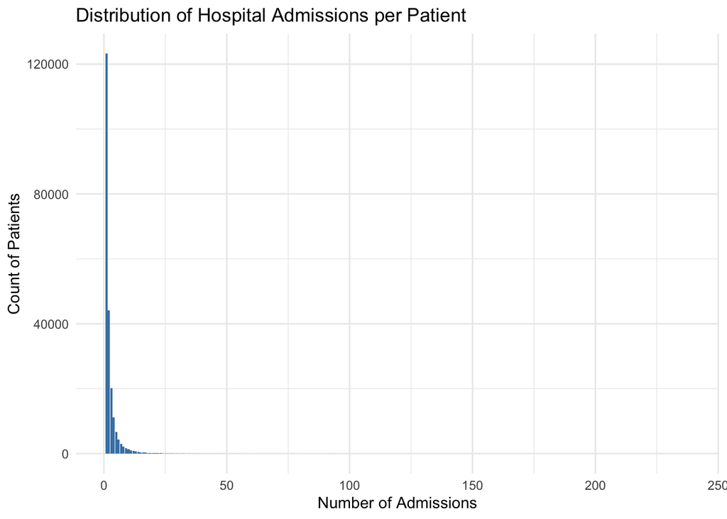

```r
admission_counts <- admissions_tble %>%
  count(subject_id) %>%
  arrange(desc(n))

ggplot(admission_counts, aes(x = n)) +
  geom_bar(fill = "steelblue") +
  labs(title = "Distribution of Hospital Admissions per Patient",
       x = "Number of Admissions",
       y = "Count of Patients") +
  theme_minimal()
```

# Most patients have only one hospital admission,

# but a small subset has an extremely high number of admissions (e.g., 50+ times).

# Patients with excessive admissions might represent chronic disease cases or

# special cases requiring frequent hospital visits.

# Further investigation is needed to check for potential data entry errors

# among patients with more than 50 admissions.

```r
admissions_tble %>%
  count(subject_id) %>%
  filter(n > 50)
```

```
# A tibble: 119 × 2
   subject_id     n
        <dbl> <int>
 1   10108435    53
 2   10123949    56
 3   10264646    94
 4   10312715    51
 5   10427568    63
 6   10577647    89
 7   10578325    74
 8   10580201    66
 9   10714009   163
10   10913302    78
# ℹ 109 more rows
```

# The number of admissions at midnight (00:00) is unusually high,

# possibly due to a default system value (e.g., missing times being recorded as 00:00).

# The peak in admissions from 3 PM to 9 PM may reflect normal hospital admission patterns.

# The spike at midnight is likely a system default; we will check whether admittime = “00:00:00”

# corresponds to missing data being automatically filled.

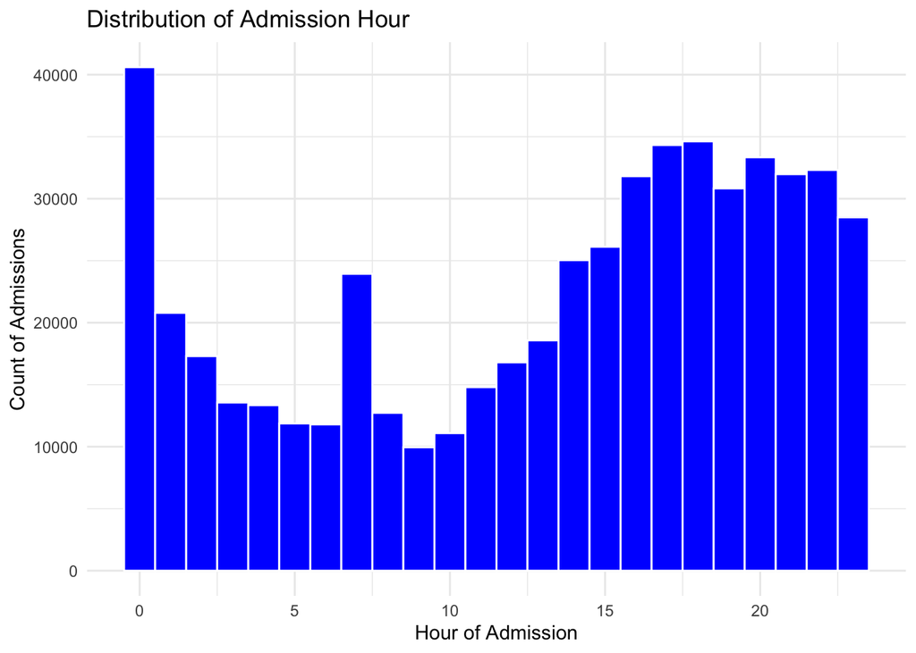

```r
admissions_tble %>%
  mutate(admit_hour = hour(admittime)) %>%
  ggplot(aes(x = admit_hour)) +
  geom_histogram(binwidth = 1, fill = "blue", color = "white") +
  labs(title = "Distribution of Admission Hour",
       x = "Hour of Admission",
       y = "Count of Admissions") +
  theme_minimal()
```

```r
admissions_tble %>%
  filter(hour(admittime) == 0) %>%
  count(admittime)
```

```
# A tibble: 36,153 × 2
   admittime               n
   <dttm>              <int>
 1 2110-01-12 00:00:00     1
 2 2110-01-12 00:34:00     1
 3 2110-01-13 00:00:00     1
 4 2110-01-23 00:00:00     1
 5 2110-01-27 00:10:00     1
 6 2110-01-27 00:32:00     1
 7 2110-01-28 00:00:00     1
 8 2110-01-28 00:12:00     1
 9 2110-01-31 00:00:00     1
10 2110-02-03 00:00:00     1
# ℹ 36,143 more rows
```

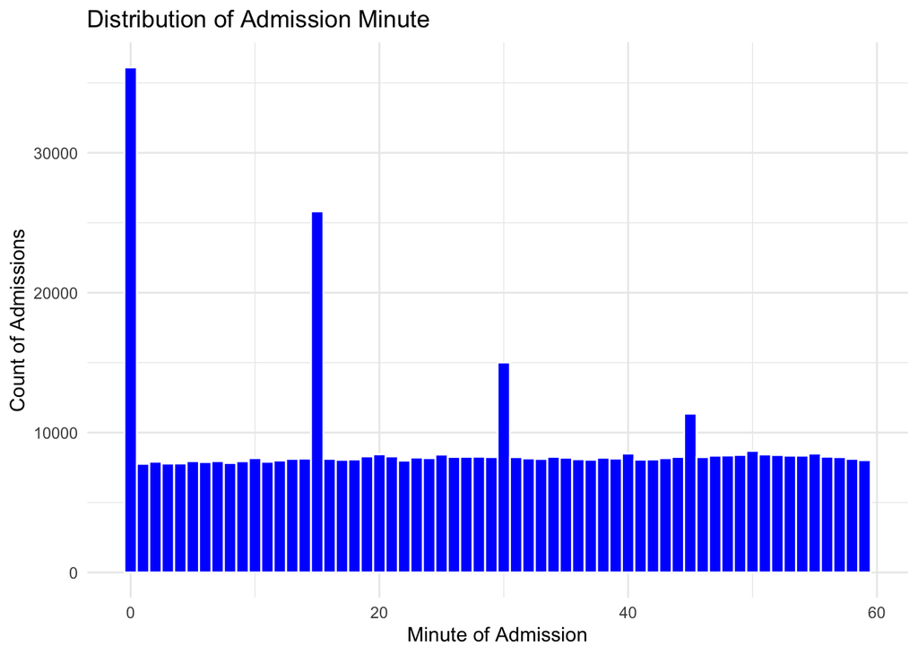

```r
admissions_tble %>%
  mutate(admit_minute = minute(admittime)) %>%
  ggplot(aes(x = admit_minute)) +
  geom_histogram(binwidth = 1, fill = "blue", color = "white") +
  labs(title = "Distribution of Admission Minute",
       x = "Minute of Admission",
       y = "Count of Admissions") +
  theme_minimal()
```